# Capitulo 3

```r
# correr si es necesario
# install.packages('ggplot2')

# Libreria a utilizar
library(ggplot2)
```

# Proceso de Poisson

### 3.2 Simulaciones en R

*Simulacion 3.1*. Al simular una trayectoria de un proceso de Poisson, necesitamos primero simular tiempos entre llegadas distribuidos exponencialmente. Basamos nuestras simulaciones en variables aleatorias uniforma estándar y utilizamos el método de inversión de la función de distribución acumulativa para obtener variables aleatorias distribuidas exponencialmente: si u~Unif(0,1), entonces $-\frac{1}{\lambda}~ln(1/u)$ es exponencial con media $1/\lambda$. Note como 1-u es algos $Unif(0,1)$, podemos simplificar la expresión para las variables aleatorias exponenciales como: $-\frac{1}{\lambda}$ En u.

Para trazar la trayectoria simulada, utilizamos la función *segment()* que toma como argumentos vectores de extremos izquierdo y derecho. A continuación presentamos el código y el gráfico de la trayectoria de un proceso de Poisson con tasa 2 que se detiene cuando realiza el 20º salto.

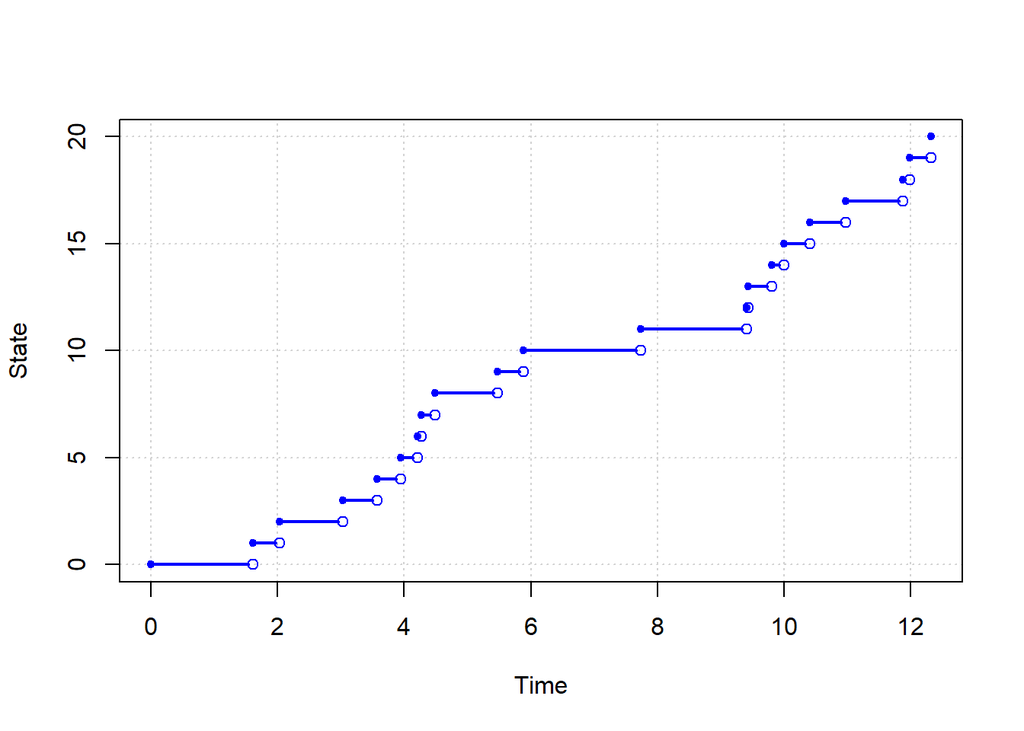

```r
# Especificamos parametrox
lambda <- 2
njumps <- 20

# Definimos el estado
N <- 0 : njumps

# Establecemos el tiempo como un vector
time <- c()

# Ajustamos el valor inicial del tiempo
time[1] <- 0

# Especificamos la semilla
set.seed(333422)

# Simulamos la trajectoria
for (i in 2:(njumps + 1))
  time[i] <- time[i-1] + round((-1/lambda) * log(runif(1)), 2)

# Graficamos la trayectoria
# type = 'n' dibuja un marco vacío sin gráfico
plot(time, N, type='n', xlab = 'Time', ylab = 'State', panel.first = grid())

segments(time[-length(time)], N[-length(time)],
time[-1]-0.07, N[-length(time)], lwd=2, col="blue")

points(time, N, pch=20, col='blue')
points(time[-1], N[-length(time)], pch=1, col='blue')
```